# Project 1

Author: Jeet Patel

### Task 1:

##### Question 1

The correct usage of `abline` to add a vertical line is `abline(v = 2)`, **not** `abline(x = 2)`.

##### Question 2

I am going to knit to an HTML file. To convert it to a PDF, I will open the HTML file in the browser, print it, and save it as a PDF.

##### Question 3

The difference between a `.pdf` file and an `.rmd` file is that `.rmd` is a script-like document containing R code and markdown, whereas a PDF is the final output document that is not easily editable.

```r
library(dplyr)
library(readr)
library(tidyr)
library(moments)
```

### Task 2: Converting Workout_Type, Experience_Level, and Gender to Factors

```r
gym_data <- read.csv("gym.csv")

gym_data$Workout_Type <- as.factor(gym_data$Workout_Type)
gym_data$Experience_Level <- factor(gym_data$Experience_Level, levels = c(1, 2, 3), ordered = TRUE)
gym_data$Gender <- as.factor(gym_data$Gender)

summary(gym_data)
```

```
##       Age            Weight           Height         Max_BPM
##  Min.   :18.00   Min.   : 40.00   Min.   :1.500   Min.   :160.0
##  1st Qu.:28.00   1st Qu.: 58.10   1st Qu.:1.620   1st Qu.:170.0
##  Median :40.00   Median : 70.00   Median :1.710   Median :180.0
##  Mean   :38.68   Mean   : 73.85   Mean   :1.723   Mean   :179.9
##  3rd Qu.:49.00   3rd Qu.: 86.00   3rd Qu.:1.800   3rd Qu.:190.0
##  Max.   :59.00   Max.   :129.90   Max.   :2.000   Max.   :199.0
##     Avg_BPM       Resting_BPM    Session_Duration Calories_Burned
##  Min.   :120.0   Min.   :50.00   Min.   :0.500    Min.   : 303.0
##  1st Qu.:131.0   1st Qu.:56.00   1st Qu.:1.040    1st Qu.: 720.0
##  Median :143.0   Median :62.00   Median :1.260    Median : 893.0
##  Mean   :143.8   Mean   :62.22   Mean   :1.256    Mean   : 905.4
##  3rd Qu.:156.0   3rd Qu.:68.00   3rd Qu.:1.460    3rd Qu.:1076.0
##  Max.   :169.0   Max.   :74.00   Max.   :2.000    Max.   :1783.0
##    Workout_Type Fat_Percentage   Water_Intake   Workout_Frequency
##  Cardio  :255   Min.   :10.00   Min.   :1.500   Min.   :2.000
##  HIIT    :221   1st Qu.:21.30   1st Qu.:2.200   1st Qu.:3.000
##  Strength:258   Median :26.20   Median :2.600   Median :3.000
##  Yoga    :239   Mean   :24.98   Mean   :2.627   Mean   :3.322
##                 3rd Qu.:29.30   3rd Qu.:3.100   3rd Qu.:4.000
##                 Max.   :35.00   Max.   :3.700   Max.   :5.000
##  Experience_Level      BMI        Gender   bmi_class
##  1:376            Min.   :12.32   0:462   Length:973
##  2:406            1st Qu.:20.11   1:511   Class :character
##  3:191            Median :24.16           Mode  :character
##                   Mean   :24.91
##                   3rd Qu.:28.56
##                   Max.   :49.84
```

### Task 3: Summarize and Describe Avg_BPM

```r
summary(gym_data$Avg_BPM)
```

```
##    Min. 1st Qu.  Median    Mean 3rd Qu.    Max.
##   120.0   131.0   143.0   143.8   156.0   169.0
```

```r
# Count NAs
sum(is.na(gym_data$Avg_BPM))
```

```
## [1] 0
```

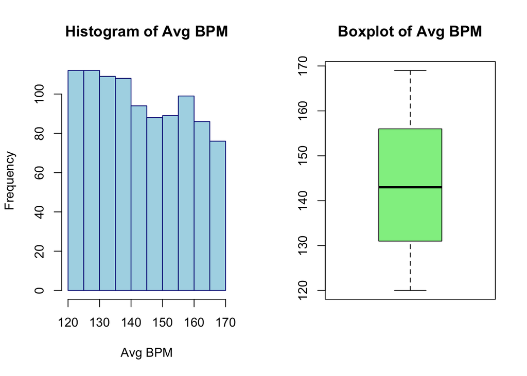

```r
# Histogram and Boxplot
par(mfrow = c(1,2))
hist(gym_data$Avg_BPM, main = "Histogram of Avg BPM", xlab = "Avg BPM", col = "lightblue", border = "navy")
boxplot(gym_data$Avg_BPM, main = "Boxplot of Avg BPM", col = "lightgreen")
```

```r
# Descriptive Statistics
mean(gym_data$Avg_BPM, na.rm = TRUE)
```

```
## [1] 143.7667
```

```r
median(gym_data$Avg_BPM, na.rm = TRUE)
```

```
## [1] 143
```

```r
sd(gym_data$Avg_BPM, na.rm = TRUE)
```

```
## [1] 14.3451
```

##### Interpretation:

The average BPM ranges approximately from 120 to 169. The histogram is fairly evenly distributed, and the boxplot shows no major outliers. The median (143) and mean (143.8) are close, indicating a roughly symmetric distribution. The standard deviation (14.35) suggests some variability in the data.

### Task 4: Summarize and Describe Workout_Type

```r
# Frequency Table
table(gym_data$Workout_Type)
```

```
##
##   Cardio     HIIT Strength     Yoga
##      255      221      258      239
```

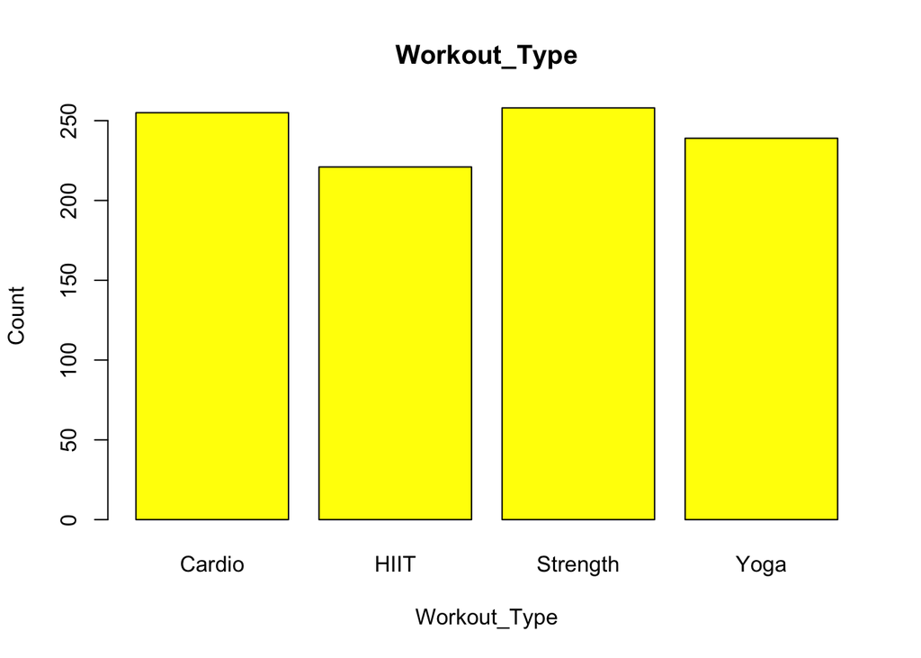

```r
# Barplot
barplot(table(gym_data$Workout_Type), main = "Workout_Type", col = "yellow", xlab = "Workout_Type", ylab = "Count")
```

##### Interpretation:

Strength and Cardio are the most common workout types (255 and 258 counts), with Yoga and HIIT slightly less common. The barplot confirms that while all types are fairly represented, Cardio and Strength have noticeably higher counts.

### Task 5: Workout_Type Varying by Experience_Level

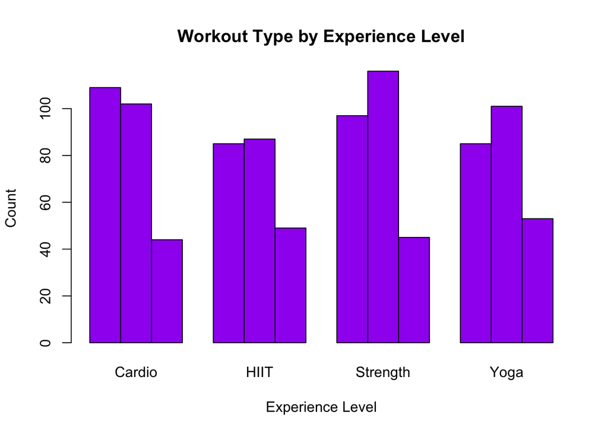

```r
# Barplot by Experience Level
barplot(table(gym_data$Experience_Level, gym_data$Workout_Type), beside = TRUE, col = "purple", main = "Workout Type by Experience Level", xlab = "Experience Level", ylab = "Count")
```

```r
# Proportional Table
workout_table <- prop.table(table(gym_data$Experience_Level, gym_data$Workout_Type))
workout_table
```

```
##
##         Cardio       HIIT   Strength       Yoga
##   1 0.11202467 0.08735868 0.09969168 0.08735868
##   2 0.10483042 0.08941418 0.11921891 0.10380267
##   3 0.04522097 0.05035971 0.04624872 0.05447071
```

##### Interpretation:

The workout type distribution is similar across experience levels. For example, beginners have roughly 11.2% Cardio, 8.7% HIIT, 9.9% Strength, and 8.7% Yoga, suggesting no strong variation by experience.

### Task 6: Normality Test for Calories_Burned

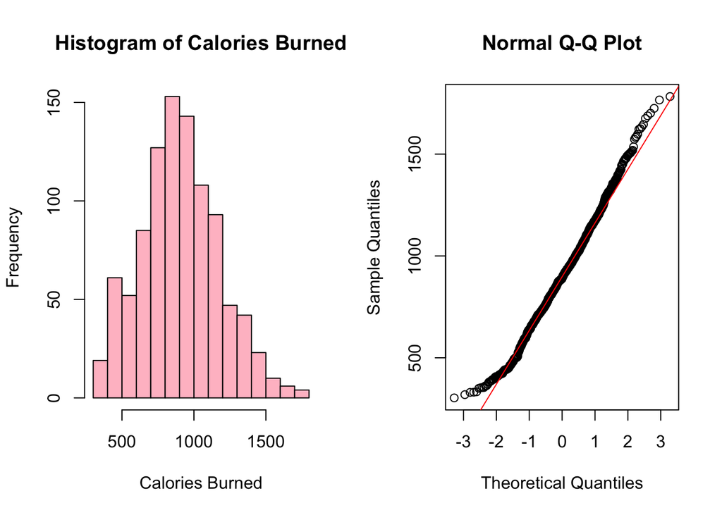

```r
# Histogram and Q-Q Plot
par(mfrow = c(1,2))
hist(gym_data$Calories_Burned, main = "Histogram of Calories Burned", xlab = "Calories Burned", col = "pink")
qqnorm(gym_data$Calories_Burned)
qqline(gym_data$Calories_Burned, col = "red")
```

```r
# Skewness and Kurtosis
skewness(gym_data$Calories_Burned)
```

```
## [1] 0.2778918
```

```r
kurtosis(gym_data$Calories_Burned)
```

```
## [1] 2.938077
```

```r
# Shapiro-Wilk Test
shapiro.test(gym_data$Calories_Burned)
```

```
##
##  Shapiro-Wilk normality test
##
## data:  gym_data$Calories_Burned
## W = 0.99176, p-value = 2.982e-05
```

##### Analysis:

Graphical diagnostics (histogram, Q-Q plot) suggest approximate normality. Skewness (0.278) and kurtosis (2.94) are close to values expected under normality. However, the Shapiro-Wilk test rejects normality (p < 0.01), indicating some deviation from a perfect normal distribution. Due to this, parametric analyses should be interpreted with caution.

### Task 7: BMI Class and Water Intake

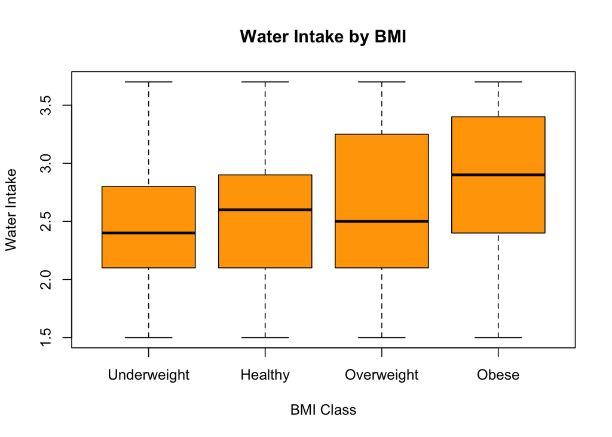

```r
gym_data$bmi_class <- cut(gym_data$BMI,
                          breaks = c(-Inf, 18.5, 25, 30, Inf),
                          labels = c("Underweight", "Healthy", "Overweight", "Obese"),
                          ordered_result = TRUE)

# Boxplot: Water Intake by BMI Class
boxplot(Water_Intake ~ bmi_class, data = gym_data, main = "Water Intake by BMI", xlab = "BMI Class", ylab = "Water Intake", col = "orange")
```

```r
# Summary Statistics
aggregate(Water_Intake ~ bmi_class, data = gym_data, FUN = function(x) c(mean = mean(x, na.rm = TRUE), sd = sd(x, na.rm = TRUE)))
```

```
##     bmi_class Water_Intake.mean Water_Intake.sd
## 1 Underweight         2.4732143       0.5418391
## 2     Healthy         2.5754054       0.5869082
## 3  Overweight         2.6000000       0.6393437
## 4       Obese         2.8932292       0.5430243
```

##### Analysis:

Water intake tends to increase as BMI class increases. Obese individuals show the highest average water intake, with the boxplot and summary statistics supporting this trend.

### Task 8: Hypothesis Test on Calories_Burned (Mean > 890)

```r
test_Calorie <- t.test(gym_data$Calories_Burned, mu = 890, alternative = "greater", conf.level = 0.98)
test_Calorie
```

```
##
##  One Sample t-test
##
## data:  gym_data$Calories_Burned
## t = 1.7645, df = 972, p-value = 0.03898
## alternative hypothesis: true mean is greater than 890
## 98 percent confidence interval:
##  887.4475      Inf
## sample estimates:
## mean of x
##  905.4224
```

##### Conclusion:

Since the p-value (0.03898) is greater than the significance level (0.02), we fail to reject the null hypothesis that mean calories burned is ≤ 890. There is insufficient evidence to conclude the mean calories burned is greater than 890.

### Task 9: Hypothesis Test on Session_Duration by Gender

```r
# Normality tests by Gender
shapiro.test(gym_data$Session_Duration[gym_data$Gender == 1])
```

```
##
##  Shapiro-Wilk normality test
##
## data:  gym_data$Session_Duration[gym_data$Gender == 1]
## W = 0.98419, p-value = 2.36e-05
```

```r
shapiro.test(gym_data$Session_Duration[gym_data$Gender == 0])
```

```
##
##  Shapiro-Wilk normality test
##
## data:  gym_data$Session_Duration[gym_data$Gender == 0]
## W = 0.98552, p-value = 0.0001461
```

```r
# Independent t-test
test_Session <- t.test(Session_Duration ~ Gender, data = gym_data, var.equal = TRUE, conf.level = 0.97)
test_Session
```

```
##
##  Two Sample t-test
##
## data:  Session_Duration by Gender
## t = 0.38019, df = 971, p-value = 0.7039
## alternative hypothesis: true difference in means between group 0 and group 1 is not equal to 0
## 97 percent confidence interval:
##  -0.03950535  0.05625800
## sample estimates:
## mean in group 0 mean in group 1
##        1.260823        1.252446
```

##### Conclusion:

The p-value (0.7039) is greater than the significance level (0.03), so we fail to reject the null hypothesis of no difference in session duration between genders.